# Mini Projeto 01

Aprendizado Não-Supervisionado - Professor Mateus Mendelson

Integrantes: Nasser Santiago Boan, Emmanuel Moreira, Harlan Martins

O objetivo desse projeto é implementar um algoritmo KMeans. O KMeans é um algoritmo de clusterização de aprendizado não supervisionado, muito utilizado para procurar subsets dentro um conjunto de dados que se assemelham em termos de suas características X.

## Preparando os dados

Para que os dados estejam prontos para ser usados devemos, inicialmente, executar o script 'make_dataset.py'. Conforme abaixo.

```python
!python src/make_dataset.py
```

```
>> Lendo e tratando dataset!
>> Dataset criado em 'data/meu_dataset.csv'
>> O Dataset possui 1570 linhas e 3 colunas.
```

Com o dataset carregado e criado, podemos agora começar a implementação do algoritmo. O algoritmo será implementado com o nome de classe MyKMeans.

```python
import pandas as pd
import plotly.express as px
import plotly.graph_objects as go
import numpy as np
import math
import numpy as np

class MyKMeans:
    def __init__(self,k=3,max_iter=300,tol=0.0001,data=None):
        self.k = k
        self.max_iter = max_iter
        self.tol = tol
        self.data = data
        self.centroids = []

    def _initialize_centroids(self):
        quant_quantis = 1/self.k
        initial_centroids = []
        for k in range(1,self.k+1):
            initial_centroids.append([np.quantile(self.data[:,0],k*quant_quantis),np.quantile(self.data[:,1],k*quant_quantis)])
        return np.array(initial_centroids)

    def fit_k_means(self,verbose=0):
        self.centroids = self._initialize_centroids()
        stop = self.centroids.copy()
        count = 0
        ## iterando sobre a quantidade max_iter
        for n_iter in range(self.max_iter): # = 300
            ## criando os clusters
            classification = {}
            for cluster in range(self.k): #k = 3
                classification[cluster] = []
            ## calculando as distancias
            for point in self.data: #df[['cases','deaths']].values
                distancias = [math.sqrt((centroid[0] - point[0])**2 + (centroid[1] - point[1])**2) for centroid in self.centroids]
                ## achando o indice do menor valor na lista distancias
                cluster = np.argmin(distancias)
                ## adicionando esse ponto ao cluster
                classification[cluster].append([value for value in point])

            ## atribuindo novos centroids
            for cluster in classification:
                self.centroids[cluster] = np.mean(classification[cluster],axis=0)
            ## implementando valor de tolerância
            if np.allclose(self.centroids, stop, atol=self.tol):
                break
            stop = self.centroids.copy()
            ## contando iterações
            count += 1


        if verbose == 1 :
            print('Número de iterações: {}'.format(count))

        self.stop = stop
        self.classification = classification

    def show_plot(self):

        if self.k <= 10:

            data_framed = []

            for cluster in self.classification:
                for point in self.classification[cluster]:
                    point.append(cluster)
                    data_framed.append(point)

            df_plot = pd.DataFrame(data_framed,columns=['cases','deaths','cluster'])
            df_plot['cluster'] = df_plot['cluster'].astype('str')

            fig = px.scatter(df_plot, x = 'cases', y = 'deaths', color = 'cluster', color_discrete_sequence=px.colors.qualitative.Plotly[:self.k],title='Data and Centroids')
            fig.add_scatter(x = self.stop[:,0], y = self.stop[:,1],mode='markers',name='Centroid',marker=dict(size=[20 for _ in range(self.k)],symbol='x',color=px.colors.qualitative.Plotly[:self.k]))

            fig.show()

        else:
            raise ValueError('plot can only be constructed with 10 or less clusters.')

    def labels_(self):

        labels = []

        for cluster in range(self.k):
            for i in range(len(self.classification[cluster])):
                labels.append(cluster)

        return labels

    def distances_(self,method):

        if method == 'mean':
            """ O desafio pede a média de todas as distâncias a seus referentes clusters """
            dist = {}

            for cluster in self.classification:
                dist[cluster] = np.mean([math.sqrt((self.stop[cluster][0] - point[0])**2 + (self.stop[cluster][1] - point[1])**2) for point in self.classification[cluster]])

            return dist

        elif method == 'inertia':
            """ Já inertia pede a soma """

            dist = {}

            for cluster in self.classification:
                dist[cluster] = np.sum([((self.stop[cluster][0] - point[0])**2 + (self.stop[cluster][1] - point[1])**2) for point in self.classification[cluster]])

            inertia = sum(dist.values())

            return inertia

    def try_k(self,how_many=10):

        data = []

        self.original_k = self.k

        for k in range(2,how_many):
            self.k = k
            self.fit_k_means()
            data.append(self.distances_('inertia'))


        fig = go.Figure(data=go.Scatter(x = list(range(2,how_many)), y = data,marker_line_color="midnightblue", marker_color="lightskyblue",
                           marker_line_width=2, marker_size=7))
        fig.update_layout(title='Finding the Elbow Point')
        fig.show()
```

Com o algortimo implementado acima podemos ler o dataset tratado e começar os testes.

```python
## carregando o dataset tratado

df = pd.read_csv('data/meu_dataset.csv')
print(df.shape)
df.head()
```

```
(1570, 3)
```

|  | county | cases | deaths |
| --- | --- | --- | --- |
| 0 | Abbeville | 84 | 0 |
| 1 | Acadia | 741 | 21 |
| 2 | Accomack | 116 | 0 |
| 3 | Ada | 4264 | 41 |
| 4 | Adair | 325 | 8 |

Primeiramente vamos instanciar o algoritmo MyKMeans e guardar dentro da variável 'sol'. A construção da classe pede alguns parâmetros:

- k --> A quantidade de clusters que iremos utilizar no algoritmo;
- max_iter --> O número máximo de iterações que o algoritmo irá executar;
- tol --> O valor de tolerância na distância entre o centroide do cluster de uma iteração e sua posição na iteração anterior.
- data --> Dados para treinamento.

```python
## instanciando o algoritmo

sol = MyKMeans(k=3,data = df[['cases','deaths']].values,max_iter = 300)
```

Primeiramente vamos testar vários valores de K para descobrirmos o valor ótimo através do método Elbow. Nesse caso testaremos nosso modelos num range de 2 até 10.

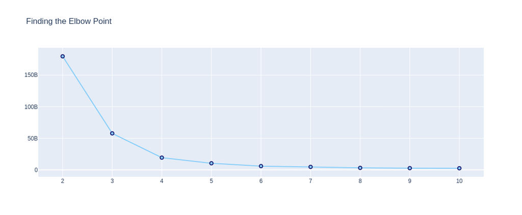

```python
sol.try_k(11)
```

No eixo Y temos a inércia de cada iteração do algoritmo. Percebemos que quando k assume o valor 4 temos um ponto de inflexão, ou seja, as inércias subsequentes não demonstram grande variação em seu valor comparando com o mesmo valor em k-1. Levando em consideração os resultados acima podemos treinar o algoritmo levando em consideração K = 4.

```python
## reinstanciando o modelo com novo valor de K

sol = MyKMeans(k=4,data = df[['cases','deaths']].values,max_iter = 300)
```

Agora estamos prontos para treinar o modelo.

```python
## treinando o modelo

sol.fit_k_means(verbose=1)
```

```
Número de iterações: 18
```

Ao treinar o algoritmo ele diz quantas iterações foram necessárias para convergir levando em consideração a tolerâncio configurada em seu instanciamento. Podemos, então verificar os pontos e seus centróides.

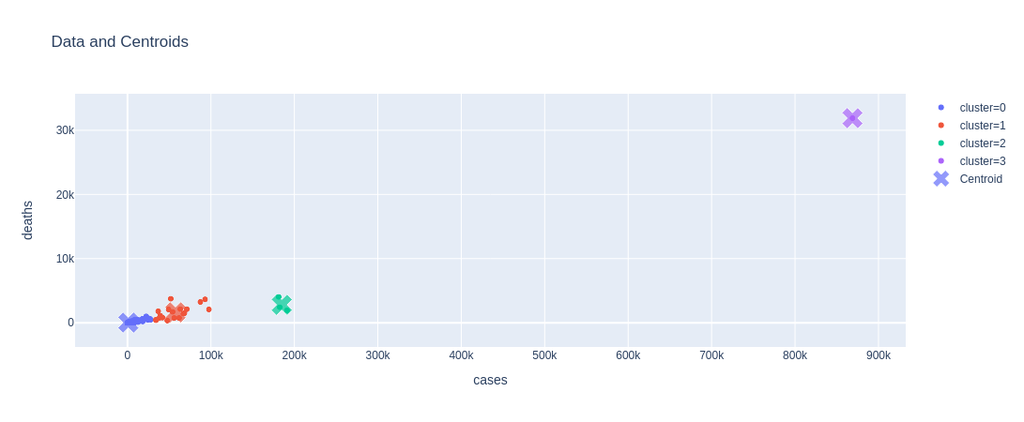

```python
sol.show_plot()
```

Cada cluster acima com seu centróide associado representam pontos, ou nesse caso cidades, que possuem um comportamento de casos e mortes de covid-19 semelhantes. Podemos analisar as médias das distâncias dos pontos de cada cluster a seu centróide.

```python
## demonstrando as distâncias

sol.distances_('mean')
```

```
{0: 1414.6360905979095, 1: 15765.070397464966, 2: 4243.742836836397, 3: 0.0}
```

Interpretando as distâncias acima podemos averiguar que o cluster 3 é o mais assertivo, visto o valor zerado, na verdade podemos dizer, com certeza, que o centróide desse cluster está exatamente na mesma coordenada do seu único ponto. Em segundo lugar, temos o cluster 0 com uma distância média de 1414, ou seja, seus pontos estão próximos ao centróide. Em terceiro lugar temos o cluster 2 demosntrando uma distância média de 4243 de seus pontos e, em último lugar, temos o cluster 1 com uma distância de 15765 esse alto valor demonstra que o cluster possui pontos esparsos.

Conferindo a inércia do algoritmo montado podemos ver que nossa versão está bem próxima da implementação do próprio KMeans do scikit-learn.

```python
## inércia do MyKMeans

sol.distances_('inertia')
```

```
19332075047.23671
```

```python
## inércia do sklearn.cluster.KMeans

from sklearn.cluster import KMeans
KMeans(n_clusters=4,max_iter=300,tol=0.0001).fit(df[['cases','deaths']].values).inertia_
```

```
19332075047.236717
```

O único downside do algoritmo montado nesse jupyter notebook é em termos de desempenho. Conforme demonstrado abaixo.

```python
%%timeit
KMeans(n_clusters=4,max_iter=300,tol=0.0001).fit(df[['cases','deaths']].values)
```

```
17.2 ms ± 642 µs per loop (mean ± std. dev. of 7 runs, 100 loops each)
```

```python
%%timeit
sol = MyKMeans(k=4,max_iter=300,tol=0.0001,data=df[['cases','deaths']].values)
sol.fit_k_means()
```

```
341 ms ± 25.2 ms per loop (mean ± std. dev. of 7 runs, 1 loop each)
```